# Population Genetics Problem Set 2

# Sydney Wyatt

### May 1, 2017

### Question 1

**A) Use a program such as R or Excel to generate a scatter plot that shows how expected allele frequency change from genetic drift depends on initial allele frequency. The x-axis should be initial allele frequency and range from 0 to 1. The y-axis should be expected change in allele frequency after one generation. Perform calculations in steps of 0.1 for a population size of 2N=20.**

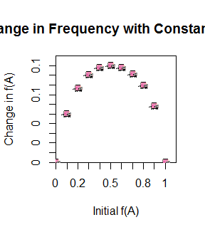

```
## $xs
##  [1] 0.0 0.1 0.2 0.3 0.4 0.5 0.6 0.7 0.8 0.9 1.0
##
## $ys
##  [1] 0.00000000 0.04415006 0.06716450 0.08002526 0.08623720 0.08809853
##  [7] 0.08625878 0.08048837 0.06982381 0.05133237 0.00000000
##
## $args
## $args$xlab
## [1] "Initial f(A)"
##
## $args$ylab
## [1] "Change in f(A)"
##
## $args$main
## [1] "Expected Change in Frequency with Constant Population Size"
##
##
## $canvas
## [1] 0.0 1.1 0.0 1.1
```

```r
#Initial allele frequency f(A)
f_A = seq(0,1, by = 0.1)

#Number of Alleles
N = 20

#Expected number of alleles in next generation
E_A = NULL

for(f in f_A){
  x = N*f     #Initial f(A)
  range_A = seq(0, x, by = 1)   #Range of alleles numbers possible
  p_A = NULL      #Possibile change in alleles

  #Calculate probability number of alleles changes and iterate over the total possible alleles
  for(i in range_A){
    p_delta = dbinom((x + i), size = N, prob = f) + dbinom((x-i), size = N, prob = f)
    p_A = append(p_A, values = p_delta)
  }
  #calculate the outcome of possible allele changes
  v = NULL
  for(i in range_A){
    v = append(v, values = i/N)
  }
  #Calculate E_A and add to initial vector
  E_A = append(E_A, sum(v*p_A))
}

#Graph!

catplot(f_A, E_A, size = 0.1, cat = 11, xlab = "Initial f(A)", ylab = "Change in f(A)", main = "Expected Change in Frequency with Constant Population Size")
```

**B) Use the same program to generate a scatter plot that shows how expected allele frequency change from genetic drift depends on population size. The x-axis should be population size and range from 2N=10 to 2N=100. The y-axis should be expected change in allele frequency after one generation. Perform calculations in steps of 10 with an allele frequency of 0.5.**

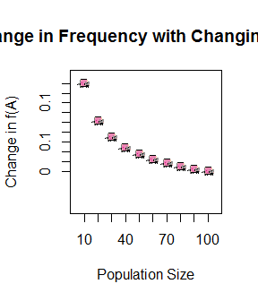

```
## $xs
##  [1]  10  20  30  40  50  60  70  80  90 100
##
## $ys
##  [1] 0.12304688 0.08809853 0.07223222 0.06268534 0.05613759 0.05128909
##  [7] 0.04751274 0.04446394 0.04193556 0.03979462
##
## $args
## $args$xlab
## [1] "Population Size"
##
## $args$ylab
## [1] "Change in f(A)"
##
## $args$main
## [1] "Expected Change in Frequency with Changing Population Size"
##
##
## $canvas
## [1] 0.0 1.1 0.0 1.1
```

```r
#Initial population size
init_pop = seq(10, 100, by = 10)

#Allele Frequency f(A)
f_A = 0.5

#Expected change in allele frequency
E_A = NULL

for(n in init_pop){
  x = n*f_A     #initial number of alleles
  range_A = seq(0, x, by=1)   #Range of possible alleles
  p_A = NULL  #Probability of change in number of alleles

  #Calculate probability allele count changes
  for(i in range_A){
    p_delta = dbinom((x+i), size = n, prob = f_A) + dbinom((x-i), size = n, prob = f_A)
    p_A = append(p_A, values = p_delta)
  }
#Calculate value of outcome
  v = NULL
  for(i in range_A){
    v = append(v, values = i/n)
  }
  E_A = append(E_A, sum(v*p_A))
}

#Graph
catplot(init_pop, E_A, size = 0.1, cat = 11, xlab = "Population Size", ylab = "Change in f(A)", main = "Expected Change in Frequency with Changing Population Size")
```

### Question 2

**A) Use the same program to generate a scatter plot that shows the properties of selection in large populations. The x-axis should be frequency of the advantageous allele and range from 0 to 1. The y-axis should be the change in frequency of the advantageous allele after one generation of selection. Perform calculations in steps of 0.01 for each of the following six (1a, 1b, 1c, 2a, 2b, 2c) scenarios: (1) the homozygous deleterious genotype has a selection coefficient of 0.1 and the advantageous allele is (a) recessive, (b) dominant or (c) additive; (2) the homozygous deleterious genotype has a selection coefficient of 0.25 and the advantageous allele is (a) recessive, (b) dominant or (c) additive.**

```r
#Define function for recessive advantageous allele given S of "bad" genotype & frequency of "good" allele
recessive <- function(Sb, fg) {
  Sg = 0
  Shet = Sb
  fb = 1 - fg
  New.freq = ((fg^2)*(1-Sg)+(fg)*(fb)*(1-Shet))/((fg^2)*(1-Sg)+2*(fg)*(fb)*(1-Shet)+(fb^2)*(1-Sb))
  Change.in.freq = New.freq - fg
  return(Change.in.freq)
}

#Define function for dominant advantageous allele given S of "bad" genotype & frequency of "good" allele
dominant <- function(Sb, fg) {
  Sg = Shet = 0
  fb = 1 - fg
  New.freq = ((fg^2)*(1-Sg)+(fg)*(fb)*(1-Shet))/((fg^2)*(1-Sg)+2*(fg)*(fb)*(1-Shet)+(fb^2)*(1-Sb))
  Change.in.freq = New.freq - fg
  return(Change.in.freq)
}

#Define function for additive advantageous allele given S of "bad" genotype & frequency of "good" allele
#Assuming that selection for heterozygotes is half of the "bad" genotype's selection
additive <- function(Sb, fg) {
  Sg = 0
  Shet = 0.5*Sb
  fb = 1 - fg
  New.freq = ((fg^2)*(1-Sg)+(fg)*(fb)*(1-Shet))/((fg^2)*(1-Sg)+2*(fg)*(fb)*(1-Shet)+(fb^2)*(1-Sb))
  Change.in.freq = New.freq - fg
  return(Change.in.freq)
}
```

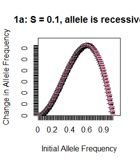

```
## $xs
##   [1] 0.00 0.01 0.02 0.03 0.04 0.05 0.06 0.07 0.08 0.09 0.10 0.11 0.12 0.13
##  [15] 0.14 0.15 0.16 0.17 0.18 0.19 0.20 0.21 0.22 0.23 0.24 0.25 0.26 0.27
##  [29] 0.28 0.29 0.30 0.31 0.32 0.33 0.34 0.35 0.36 0.37 0.38 0.39 0.40 0.41
##  [43] 0.42 0.43 0.44 0.45 0.46 0.47 0.48 0.49 0.50 0.51 0.52 0.53 0.54 0.55
##  [57] 0.56 0.57 0.58 0.59 0.60 0.61 0.62 0.63 0.64 0.65 0.66 0.67 0.68 0.69
##  [71] 0.70 0.71 0.72 0.73 0.74 0.75 0.76 0.77 0.78 0.79 0.80 0.81 0.82 0.83
##  [85] 0.84 0.85 0.86 0.87 0.88 0.89 0.90 0.91 0.92 0.93 0.94 0.95 0.96 0.97
##  [99] 0.98 0.99 1.00
##
## $ys
##   [1] 0.000000e+00 1.099988e-05 4.355362e-05 9.699030e-05 1.706363e-04
##   [6] 2.638156e-04 3.758497e-04 5.060578e-04 6.537573e-04 8.182636e-04
##  [11] 9.988901e-04 1.194949e-03 1.405751e-03 1.630605e-03 1.868819e-03
##  [16] 2.119701e-03 2.382556e-03 2.656691e-03 2.941411e-03 3.236020e-03
```

[output cut: 31 more lines]

```r
#Now we use the above functions to calculate frequency of "good" allele in next generation

#Define allele frequency
good.allele.freq = seq(0,1, by = 0.01)   #0, 0.01, 0.02, ..... 1
bad.S = 0.1

#If "good" allele is recessive:
NextGenfreq.recessive = c()
for(i in good.allele.freq){
  f = recessive(bad.S, i)
  NextGenfreq.recessive = append(NextGenfreq.recessive, f)
}

#plot it!
catplot(good.allele.freq, NextGenfreq.recessive, size = 0.1, cat = 11, xlab = "Initial Allele Frequency", ylab = "Change in Allele Frequency", main = "1a: S = 0.1, allele is recessive")
```

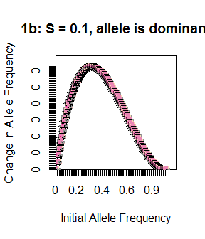

```
## $xs
##   [1] 0.00 0.01 0.02 0.03 0.04 0.05 0.06 0.07 0.08 0.09 0.10 0.11 0.12 0.13
##  [15] 0.14 0.15 0.16 0.17 0.18 0.19 0.20 0.21 0.22 0.23 0.24 0.25 0.26 0.27
##  [29] 0.28 0.29 0.30 0.31 0.32 0.33 0.34 0.35 0.36 0.37 0.38 0.39 0.40 0.41
##  [43] 0.42 0.43 0.44 0.45 0.46 0.47 0.48 0.49 0.50 0.51 0.52 0.53 0.54 0.55
##  [57] 0.56 0.57 0.58 0.59 0.60 0.61 0.62 0.63 0.64 0.65 0.66 0.67 0.68 0.69
##  [71] 0.70 0.71 0.72 0.73 0.74 0.75 0.76 0.77 0.78 0.79 0.80 0.81 0.82 0.83
##  [85] 0.84 0.85 0.86 0.87 0.88 0.89 0.90 0.91 0.92 0.93 0.94 0.95 0.96 0.97
##  [99] 0.98 0.99 1.00
##
## $ys
##   [1] 0.000000e+00 1.086597e-03 2.124873e-03 3.115872e-03 4.060627e-03
##   [6] 4.960154e-03 5.815453e-03 6.627514e-03 7.397308e-03 8.125797e-03
##  [11] 8.813928e-03 9.462635e-03 1.007284e-02 1.064545e-02 1.118137e-02
##  [16] 1.168149e-02 1.214667e-02 1.257778e-02 1.297569e-02 1.334122e-02
```

[output cut: 31 more lines]

```r
#If "good" allele is dominant:
NextGenfreq.dominant = c()
for(i in good.allele.freq){
  f = dominant(bad.S, i)
  NextGenfreq.dominant = append(NextGenfreq.dominant, f)
}

catplot(good.allele.freq, NextGenfreq.dominant, size = 0.1, cat = 11, xlab = "Initial Allele Frequency", ylab = "Change in Allele Frequency", main = "1b: S = 0.1, allele is dominant")
```

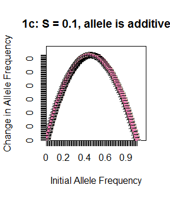

```
## $xs
##   [1] 0.00 0.01 0.02 0.03 0.04 0.05 0.06 0.07 0.08 0.09 0.10 0.11 0.12 0.13
##  [15] 0.14 0.15 0.16 0.17 0.18 0.19 0.20 0.21 0.22 0.23 0.24 0.25 0.26 0.27
##  [29] 0.28 0.29 0.30 0.31 0.32 0.33 0.34 0.35 0.36 0.37 0.38 0.39 0.40 0.41
##  [43] 0.42 0.43 0.44 0.45 0.46 0.47 0.48 0.49 0.50 0.51 0.52 0.53 0.54 0.55
##  [57] 0.56 0.57 0.58 0.59 0.60 0.61 0.62 0.63 0.64 0.65 0.66 0.67 0.68 0.69
##  [71] 0.70 0.71 0.72 0.73 0.74 0.75 0.76 0.77 0.78 0.79 0.80 0.81 0.82 0.83
##  [85] 0.84 0.85 0.86 0.87 0.88 0.89 0.90 0.91 0.92 0.93 0.94 0.95 0.96 0.97
##  [99] 0.98 0.99 1.00
##
## $ys
##   [1] 0.0000000000 0.0005493896 0.0010864745 0.0016112957 0.0021238938
##   [6] 0.0026243094 0.0031125828 0.0035887541 0.0040528634 0.0045049505
##  [11] 0.0049450549 0.0053732162 0.0057894737 0.0061938664 0.0065864333
##  [16] 0.0069672131 0.0073362445 0.0076935660 0.0080392157 0.0083732318
```

[output cut: 31 more lines]

```r
#If "good" allele is additive:
NextGenfreq.additive = c()
for(i in good.allele.freq){
  f = additive(bad.S, i)
  NextGenfreq.additive = append(NextGenfreq.additive, f)
}

catplot(good.allele.freq, NextGenfreq.additive, size = 0.1, cat = 11,  xlab = "Initial Allele Frequency", ylab = "Change in Allele Frequency", main = "1c: S = 0.1, allele is additive")
```

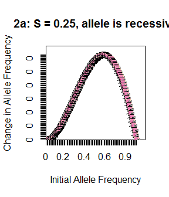

```
## $xs
##   [1] 0.00 0.01 0.02 0.03 0.04 0.05 0.06 0.07 0.08 0.09 0.10 0.11 0.12 0.13
##  [15] 0.14 0.15 0.16 0.17 0.18 0.19 0.20 0.21 0.22 0.23 0.24 0.25 0.26 0.27
##  [29] 0.28 0.29 0.30 0.31 0.32 0.33 0.34 0.35 0.36 0.37 0.38 0.39 0.40 0.41
##  [43] 0.42 0.43 0.44 0.45 0.46 0.47 0.48 0.49 0.50 0.51 0.52 0.53 0.54 0.55
##  [57] 0.56 0.57 0.58 0.59 0.60 0.61 0.62 0.63 0.64 0.65 0.66 0.67 0.68 0.69
##  [71] 0.70 0.71 0.72 0.73 0.74 0.75 0.76 0.77 0.78 0.79 0.80 0.81 0.82 0.83
##  [85] 0.84 0.85 0.86 0.87 0.88 0.89 0.90 0.91 0.92 0.93 0.94 0.95 0.96 0.97
##  [99] 0.98 0.99 1.00
##
## $ys
##   [1] 0.0000000000 0.0000329989 0.0001306492 0.0002909127 0.0005117271
##   [6] 0.0007910075 0.0011266480 0.0015165230 0.0019584886 0.0024503840
##  [11] 0.0029900332 0.0035752465 0.0042038217 0.0048735457 0.0055821963
##  [16] 0.0063275434 0.0071073506 0.0079193767 0.0087613771 0.0096311057
```

[output cut: 31 more lines]

```r
#Now we have a new S!
bad.S = 0.25

#Copy the previous code and relabel the graphs.
#If "good" allele is recessive:
NextGenfreq.recessive = c()
for(i in good.allele.freq){   #iterate over the different "good" allele frequencies
  f = recessive(bad.S, i)
  NextGenfreq.recessive = append(NextGenfreq.recessive, f)
}

#plot it!
catplot(good.allele.freq, NextGenfreq.recessive, size = 0.1, cat = 11, xlab = "Initial Allele Frequency", ylab = "Change in Allele Frequency", main = "2a: S = 0.25, allele is recessive")
```

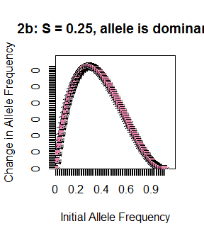

```
## $xs
##   [1] 0.00 0.01 0.02 0.03 0.04 0.05 0.06 0.07 0.08 0.09 0.10 0.11 0.12 0.13
##  [15] 0.14 0.15 0.16 0.17 0.18 0.19 0.20 0.21 0.22 0.23 0.24 0.25 0.26 0.27
##  [29] 0.28 0.29 0.30 0.31 0.32 0.33 0.34 0.35 0.36 0.37 0.38 0.39 0.40 0.41
##  [43] 0.42 0.43 0.44 0.45 0.46 0.47 0.48 0.49 0.50 0.51 0.52 0.53 0.54 0.55
##  [57] 0.56 0.57 0.58 0.59 0.60 0.61 0.62 0.63 0.64 0.65 0.66 0.67 0.68 0.69
##  [71] 0.70 0.71 0.72 0.73 0.74 0.75 0.76 0.77 0.78 0.79 0.80 0.81 0.82 0.83
##  [85] 0.84 0.85 0.86 0.87 0.88 0.89 0.90 0.91 0.92 0.93 0.94 0.95 0.96 0.97
##  [99] 0.98 0.99 1.00
##
## $ys
##   [1] 0.000000e+00 3.245472e-03 6.319253e-03 9.227224e-03 1.197505e-02
##   [6] 1.456820e-02 1.701194e-02 1.931135e-02 2.147133e-02 2.349664e-02
##  [11] 2.539185e-02 2.716138e-02 2.880952e-02 3.034042e-02 3.175807e-02
##  [16] 3.306636e-02 3.426906e-02 3.536982e-02 3.637216e-02 3.727952e-02
```

[output cut: 31 more lines]

```r
#If "good" allele is dominant:
NextGenfreq.dominant = c()
for(i in good.allele.freq){
  f = dominant(bad.S, i)
  NextGenfreq.dominant = append(NextGenfreq.dominant, f)
}

catplot(good.allele.freq, NextGenfreq.dominant, size = 0.1, cat = 11, xlab = "Initial Allele Frequency", ylab = "Change in Allele Frequency", main = "2b: S = 0.25, allele is dominant")
```

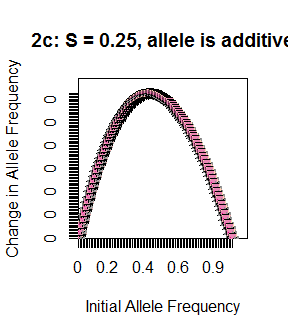

```
## $xs
##   [1] 0.00 0.01 0.02 0.03 0.04 0.05 0.06 0.07 0.08 0.09 0.10 0.11 0.12 0.13
##  [15] 0.14 0.15 0.16 0.17 0.18 0.19 0.20 0.21 0.22 0.23 0.24 0.25 0.26 0.27
##  [29] 0.28 0.29 0.30 0.31 0.32 0.33 0.34 0.35 0.36 0.37 0.38 0.39 0.40 0.41
##  [43] 0.42 0.43 0.44 0.45 0.46 0.47 0.48 0.49 0.50 0.51 0.52 0.53 0.54 0.55
##  [57] 0.56 0.57 0.58 0.59 0.60 0.61 0.62 0.63 0.64 0.65 0.66 0.67 0.68 0.69
##  [71] 0.70 0.71 0.72 0.73 0.74 0.75 0.76 0.77 0.78 0.79 0.80 0.81 0.82 0.83
##  [85] 0.84 0.85 0.86 0.87 0.88 0.89 0.90 0.91 0.92 0.93 0.94 0.95 0.96 0.97
##  [99] 0.98 0.99 1.00
##
## $ys
##   [1] 0.000000000 0.001644518 0.003245033 0.004801980 0.006315789
##   [6] 0.007786885 0.009215686 0.010602606 0.011948052 0.013252427
##  [11] 0.014516129 0.015739550 0.016923077 0.018067093 0.019171975
##  [16] 0.020238095 0.021265823 0.022255521 0.023207547 0.024122257
```

[output cut: 31 more lines]

```r
#If "good" allele is additive:
NextGenfreq.additive = c()
for(i in good.allele.freq){
  f = additive(bad.S, i)
  NextGenfreq.additive = append(NextGenfreq.additive, f)
}

#rainbowCats(good.allele.freq, NextGenfreq.additive, ptsize = 1, yspread = 0.05, xspread = 0.05, cat = 11, canvas = c(0,1.5,0,1.5))

catplot(good.allele.freq, NextGenfreq.additive, size = 0.1, cat = 11, xlab = "Initial Allele Frequency", ylab = "Change in Allele Frequency", main = "2c: S = 0.25, allele is additive")
```